# Naive Bayes aplicado al rendimiento académico de estudiantes de la FCI

# Introducción

Se aplica el clasificador **Naive Bayes** para predecir el **Rendimiento** académico de un grupo de estudiantes de la Facultad de Ciencias de la Información (FCI), a partir de cuatro variables categóricas: `TiempoEstudio`, `Asistencia`, `Participacion` y `SituacionEcon`.

# 1. Fundamento teórico: Teorema de Bayes y Naive Bayes

El Teorema de Bayes permite calcular la probabilidad de una clase $c$ dado un conjunto de evidencias (atributos) $x_1, \dots, x_n$:

$$P(c \mid x_1, \dots, x_n) = \frac{P(c) \cdot P(x_1, \dots, x_n \mid
c)}{P(x_1, \dots, x_n)}$$

El clasificador **Naive Bayes** asume independencia condicional entre los atributos dado el valor de la clase, de modo que:

$$P(x_1, \dots, x_n \mid c) = P(x_1 \mid c) \cdot P(x_2 \mid c) \cdots
P(x_n \mid c)$$

Como el denominador $P(x_1,\dots,x_n)$ es igual para todas las clases comparadas, la clase predicha es la que maximiza:

$$P(c \mid x_1, \dots, x_n) \;\propto\; P(c) \cdot \prod_{i=1}^{n} P(x_i
\mid c)$$

**Estimación de probabilidades:**

- $P(c)$ se estima como la frecuencia relativa de cada clase de `Rendimiento` en el conjunto de entrenamiento: $P(c) = n_c / N$.
- $P(x_i \mid c)$ se estima contando, dentro de cada clase, la frecuencia relativa de cada categoría del atributo (por ejemplo, $P(\text{Asistencia}=\text{Alta} \mid \text{Rendimiento}=\text{Excelente})$ es la proporción de estudiantes con Rendimiento=Excelente que tuvieron Asistencia=Alta).

# 2. Variables del estudio

**Atributos (features):**

- `TiempoEstudio`: Alto (≥15 h/semana), Medio (8-14 h/semana), Bajo (≤7 h/semana)
- `Asistencia`: Alta (≥90%), Media (75-89%), Baja (≤74%)
- `Participacion`: Alta (≥80% actividades), Media (50-79%), Baja (≤49%)
- `SituacionEcon`: Buena, Mala

**Variable objetivo (target):**

- `Rendimiento`: Excelente (≥90 pts), Bueno (80-89 pts), Regular (70-79 pts), Deficiente (≤69 pts)

# 3. Carga de paquetes

```r
library(e1071)    # Contiene la función naiveBayes()
library(caret)    # Para partición de datos y matriz de confusión
```

# 4. Datos de los estudiantes

Información de 35 estudiantes de la FCI, tabulando su tiempo de estudio, asistencia, participación y situación económica, junto con su rendimiento académico.

```r
estudiantes <- data.frame(
  TiempoEstudio  = c("Alto","Medio","Bajo","Alto","Medio","Alto","Bajo","Medio","Alto","Bajo",
                      "Alto","Medio","Bajo","Alto","Medio","Alto","Bajo","Medio","Alto","Bajo",
                      "Medio","Alto","Bajo","Medio","Alto","Bajo","Medio","Alto","Medio","Bajo",
                      "Alto","Medio","Bajo","Alto","Medio"),
  Asistencia     = c("Alta","Media","Baja","Alta","Media","Alta","Baja","Alta","Media","Baja",
                      "Alta","Media","Media","Media","Baja","Alta","Baja","Alta","Media","Media",
                      "Media","Alta","Baja","Alta","Media","Baja","Media","Alta","Media","Baja",
                      "Alta","Media","Baja","Alta","Alta"),
  Participacion  = c("Alta","Baja","Baja","Media","Media","Alta","Baja","Media","Alta","Media",
                      "Alta","Baja","Baja","Media","Media","Media","Baja","Alta","Baja","Baja",
                      "Media","Alta","Media","Media","Alta","Baja","Baja","Media","Alta","Baja",
                      "Alta","Media","Baja","Media","Alta"),
  SituacionEcon  = c("Buena","Mala","Mala","Buena","Buena","Buena","Mala","Buena","Buena","Mala",
                      "Buena","Buena","Mala","Buena","Mala","Buena","Mala","Buena","Buena","Mala",
                      "Mala","Mala","Buena","Mala","Buena","Buena","Mala","Mala","Buena","Mala",
                      "Buena","Buena","Mala","Buena","Buena"),
  Rendimiento    = c("Excelente","Regular","Deficiente","Bueno","Bueno","Excelente","Deficiente","Bueno","Excelente","Regular",
                      "Excelente","Regular","Deficiente","Bueno","Regular","Excelente","Deficiente","Excelente","Bueno","Regular",
                      "Regular","Bueno","Regular","Regular","Excelente","Deficiente","Deficiente","Bueno","Bueno","Deficiente",
                      "Excelente","Bueno","Deficiente","Excelente","Excelente"),
  stringsAsFactors = TRUE
)

str(estudiantes)
```

```
## 'data.frame':    35 obs. of  5 variables:
##  $ TiempoEstudio: Factor w/ 3 levels "Alto","Bajo",..: 1 3 2 1 3 1 2 3 1 2 ...
##  $ Asistencia   : Factor w/ 3 levels "Alta","Baja",..: 1 3 2 1 3 1 2 1 3 2 ...
##  $ Participacion: Factor w/ 3 levels "Alta","Baja",..: 1 2 2 3 3 1 2 3 1 3 ...
##  $ SituacionEcon: Factor w/ 2 levels "Buena","Mala": 1 2 2 1 1 1 2 1 1 2 ...
##  $ Rendimiento  : Factor w/ 4 levels "Bueno","Deficiente",..: 3 4 2 1 1 3 2 1 3 4 ...
```

## 4.1 Exploración inicial

```r
summary(estudiantes)
```

```
##  TiempoEstudio Asistencia Participacion SituacionEcon     Rendimiento
##  Alto :13      Alta :13   Alta :10      Buena:20      Bueno     : 9
##  Bajo :10      Baja : 9   Baja :12      Mala :15      Deficiente: 8
##  Medio:12      Media:13   Media:13                    Excelente :10
##                                                       Regular   : 8
```

```r
# Distribución de la variable objetivo
table(estudiantes$Rendimiento)
```

```
##
##      Bueno Deficiente  Excelente    Regular
##          9          8         10          8
```

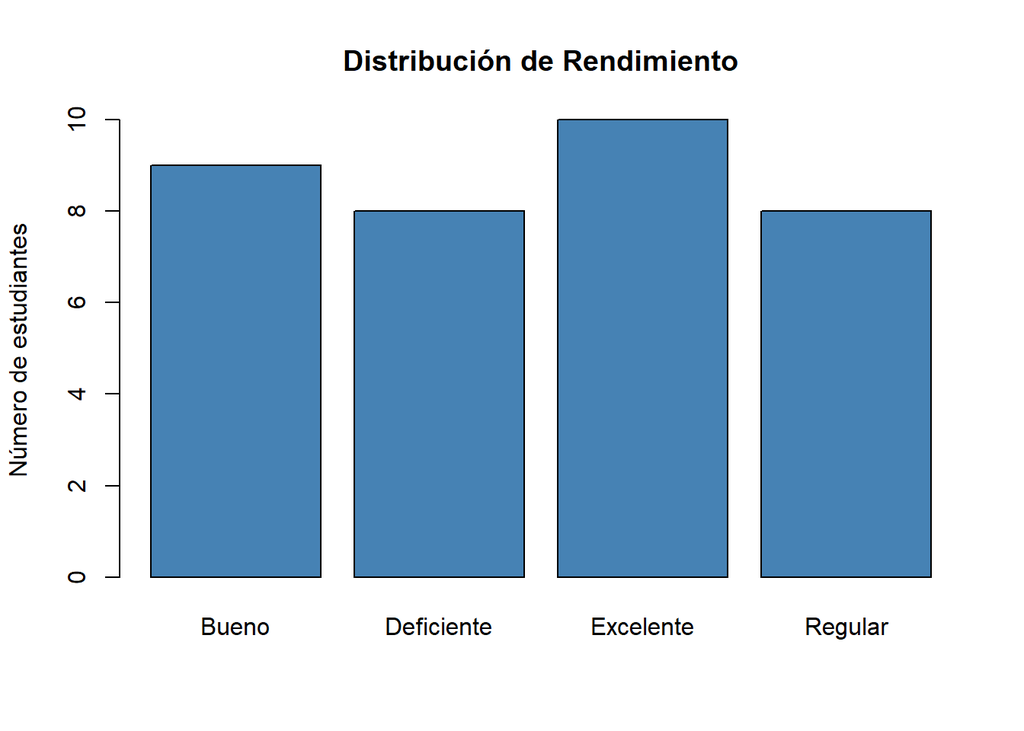

```r
barplot(table(estudiantes$Rendimiento),
        main = "Distribución de Rendimiento",
        col = "steelblue",
        ylab = "Número de estudiantes")
```

# 5. División en entrenamiento (80%) y prueba (20%)

Se utiliza una semilla fija para reproducibilidad y `createDataPartition` para mantener, en la medida de lo posible, la proporción de cada clase de `Rendimiento` en ambos conjuntos.

```r
set.seed(123)

train_index <- createDataPartition(estudiantes$Rendimiento, p = 0.8, list = FALSE)

train_data <- estudiantes[train_index, ]
test_data  <- estudiantes[-train_index, ]

dim(train_data)
```

```
## [1] 30  5
```

```r
dim(test_data)
```

```
## [1] 5 5
```

```r
table(train_data$Rendimiento)
```

```
##
##      Bueno Deficiente  Excelente    Regular
##          8          7          8          7
```

```r
table(test_data$Rendimiento)
```

```
##
##      Bueno Deficiente  Excelente    Regular
##          1          1          2          1
```

# 6. Entrenamiento del modelo Naive Bayes

La fórmula `Rendimiento ~ .` indica que se predice `Rendimiento` usando todas las demás variables como predictores. Como todas ellas son categóricas (factores), `naiveBayes()` calculará internamente las probabilidades a priori $P(c)$ y las tablas de frecuencia condicional $P(x_i \mid c)$ para cada atributo.

```r
modelo_nb <- naiveBayes(Rendimiento ~ ., data = train_data)
modelo_nb
```

```
##
## Naive Bayes Classifier for Discrete Predictors
##
## Call:
## naiveBayes.default(x = X, y = Y, laplace = laplace)
##
## A-priori probabilities:
## Y
##      Bueno Deficiente  Excelente    Regular
##  0.2666667  0.2333333  0.2666667  0.2333333
##
## Conditional probabilities:
##             TiempoEstudio
## Y                 Alto      Bajo     Medio
##   Bueno      0.5000000 0.0000000 0.5000000
##   Deficiente 0.0000000 0.8571429 0.1428571
##   Excelente  0.7500000 0.0000000 0.2500000
##   Regular    0.0000000 0.2857143 0.7142857
##
##             Asistencia
## Y                 Alta      Baja     Media
##   Bueno      0.5000000 0.0000000 0.5000000
##   Deficiente 0.0000000 0.7142857 0.2857143
##   Excelente  0.7500000 0.0000000 0.2500000
##   Regular    0.1428571 0.4285714 0.4285714
##
##             Participacion
## Y                 Alta      Baja     Media
##   Bueno      0.2500000 0.1250000 0.6250000
##   Deficiente 0.0000000 1.0000000 0.0000000
##   Excelente  0.7500000 0.0000000 0.2500000
##   Regular    0.0000000 0.2857143 0.7142857
##
##             SituacionEcon
## Y                Buena      Mala
##   Bueno      0.7500000 0.2500000
##   Deficiente 0.0000000 1.0000000
##   Excelente  1.0000000 0.0000000
##   Regular    0.2857143 0.7142857
```

Nota: en la salida del modelo, `A-priori probabilities` corresponde a $P(c)$ para cada clase de `Rendimiento`, y las tablas condicionales que siguen (`TiempoEstudio`, `Asistencia`, `Participacion`, `SituacionEcon`) corresponden a $P(x_i \mid c)$.

# 7. Predicciones sobre el conjunto de prueba

```r
predicciones <- predict(modelo_nb, test_data)
predicciones
```

```
## [1] Excelente  Bueno      Deficiente Regular    Excelente
## Levels: Bueno Deficiente Excelente Regular
```

```r
cat("\nValores reales:\n")
```

```
##
## Valores reales:
```

```r
test_data$Rendimiento
```

```
## [1] Excelente  Bueno      Regular    Deficiente Excelente
## Levels: Bueno Deficiente Excelente Regular
```

# 8. Matriz de confusión

```r
matriz_confusion <- confusionMatrix(predicciones, test_data$Rendimiento)
matriz_confusion
```

```
## Confusion Matrix and Statistics
##
##             Reference
## Prediction   Bueno Deficiente Excelente Regular
##   Bueno          1          0         0       0
##   Deficiente     0          0         0       1
##   Excelente      0          0         2       0
##   Regular        0          1         0       0
##
## Overall Statistics
##
##                Accuracy : 0.6
##                  95% CI : (0.1466, 0.9473)
##     No Information Rate : 0.4
##     P-Value [Acc > NIR] : 0.3174
##
##                   Kappa : 0.4444
##
##  Mcnemar's Test P-Value : NA
##
## Statistics by Class:
##
##                      Class: Bueno Class: Deficiente Class: Excelente
## Sensitivity                   1.0             0.000              1.0
## Specificity                   1.0             0.750              1.0
## Pos Pred Value                1.0             0.000              1.0
## Neg Pred Value                1.0             0.750              1.0
## Prevalence                    0.2             0.200              0.4
## Detection Rate                0.2             0.000              0.4
## Detection Prevalence          0.2             0.200              0.4
## Balanced Accuracy             1.0             0.375              1.0
##                      Class: Regular
## Sensitivity                   0.000
## Specificity                   0.750
## Pos Pred Value                0.000
## Neg Pred Value                0.750
## Prevalence                    0.200
## Detection Rate                0.000
## Detection Prevalence          0.200
## Balanced Accuracy             0.375
```

# 9. Predicción de un nuevo estudiante (ejemplo)

Como ejemplo adicional, se predice el rendimiento de un estudiante hipotético con tiempo de estudio medio, asistencia alta, participación media y buena situación económica.

```r
nuevo_estudiante <- data.frame(
  TiempoEstudio = factor("Medio", levels = levels(estudiantes$TiempoEstudio)),
  Asistencia    = factor("Alta",  levels = levels(estudiantes$Asistencia)),
  Participacion = factor("Media", levels = levels(estudiantes$Participacion)),
  SituacionEcon = factor("Buena", levels = levels(estudiantes$SituacionEcon))
)

predict(modelo_nb, nuevo_estudiante)
```

```
## [1] Bueno
## Levels: Bueno Deficiente Excelente Regular
```

```r
# Probabilidades posteriores por clase
predict(modelo_nb, nuevo_estudiante, type = "raw")
```

```
##          Bueno   Deficiente Excelente    Regular
## [1,] 0.6428839 6.857428e-10 0.2571536 0.09996251
```

# 10. Conclusiones

Naive Bayes con atributos categóricos estima $P(x_i \mid c)$ mediante tablas de frecuencia por clase, en lugar de una función de densidad continua. La matriz de confusión y la exactitud obtenida dependen fuertemente del tamaño y la calidad de la muestra real recolectada; con muestras pequeñas (20-50 estudiantes) los resultados pueden variar bastante según la partición entrenamiento/prueba.